# Summary of Electrical Conductivity data for Subaqueous Soils in MMA 12-TOL

Jacob Isleib

2018-05-01

# Load data

```r
# Author:Jacob Isleib
# Analysis of EC and EC 1:5 data

setwd("C:/workspace/CZSS")

kssl <- read.csv(file = 'aaMASTER_StoltURIdata_for_KSSL.csv', header = TRUE)
colnames(kssl)[4] <- "labsampnum"
kssl.ec <- kssl[, c(3, 4, 7, 8, 21, 22, 23, 26, 31, 35)]
kssl.ec <- kssl.ec[complete.cases(kssl.ec), ]
kssl.ec.num <- kssl.ec[, c(3, 5, 6, 7, 9, 10)]
kssl.15ec <- kssl[, c(3, 4, 7, 8, 21, 22, 23, 26, 31, 43)]
kssl.15ec <- kssl.15ec[complete.cases(kssl.15ec), ]
kssl.15ec.num <- kssl.15ec[, c(3, 5, 6, 7, 9, 10)]
```

# EC

## Scatterplot Matrix and Correlation Matrix

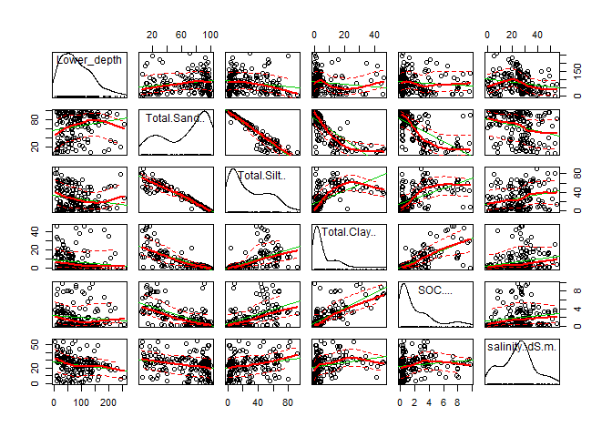

```r
## EC

library(car)
spm(kssl.ec.num)
```

```r
cor(kssl.ec.num)
```

```
##                 Lower_depth Total.Sand.. Total.Silt.. Total.Clay..
## Lower_depth      1.00000000    0.1952620   -0.1969804   -0.1291954
## Total.Sand..     0.19526198    1.0000000   -0.9616715   -0.7726220
## Total.Silt..    -0.19698037   -0.9616715    1.0000000    0.5689818
## Total.Clay..    -0.12919543   -0.7726220    0.5689818    1.0000000
## SOC....         -0.09656669   -0.6622402    0.5426199    0.7302676
## salinity..dS.m. -0.18814935   -0.2707615    0.2533853    0.2260016
##                     SOC.... salinity..dS.m.
## Lower_depth     -0.09656669      -0.1881493
## Total.Sand..    -0.66224016      -0.2707615
## Total.Silt..     0.54261990       0.2533853
## Total.Clay..     0.73026759       0.2260016
## SOC....          1.00000000       0.1435937
## salinity..dS.m.  0.14359374       1.0000000
```

## ANOVA and Tukey Honest Significant Differences will be used to evaluate texture class and EC

```r
amod <- aov(salinity..dS.m. ~ class, data=kssl.ec)
amod
```

```
## Call:
##    aov(formula = salinity..dS.m. ~ class, data = kssl.ec)
##
## Terms:
##                     class Residuals
## Sum of Squares   3644.066 22734.763
## Deg. of Freedom        19       152
##
## Residual standard error: 12.22991
## Estimated effects may be unbalanced
```

```r
summary(amod)
```

```
##              Df Sum Sq Mean Sq F value Pr(>F)
## class        19   3644   191.8   1.282  0.203
## Residuals   152  22735   149.6
```

```r
print(model.tables(amod, "effects", se = TRUE))
```

```
## Design is unbalanced - use se.contrast() for se's
```

```
## Tables of effects
##
##  class
##          cl    cos   cosl    fs    fsl     l    l    lcos     lfs      ls
##     -0.0644 -2.831 -2.799 -6.27  5.489 5.077 7.621 -3.757  0.3665 -0.1282
## rep  4.0000 16.000  4.000 26.00 14.000 8.000 1.000  4.000 13.0000  3.0000
##          s    s    scl    si    sic  sicl    sil     sl    vfs  vfsl
##     -2.043 1.467 2.021 15.22 -2.777 3.364  4.786 -8.706 -3.029 3.739
## rep 20.000 1.000 1.000  1.00  4.000 3.000 32.000  6.000  2.000 9.000
```

```r
tukey <- TukeyHSD(amod, "class")
ec.hsd.table <- as.data.frame(tukey$class)
ec.hsd.table[ order(ec.hsd.table$`p adj`), ]
```

```
##                   diff         lwr       upr      p adj
## sil-fs     11.05596411  -0.5929326 22.704861 0.08543496
## fsl-fs     11.75884236  -2.8666928 26.384378 0.30236680
## sl-sil    -13.49186154 -33.1197529  6.136030 0.60107061
## sl-fsl    -14.19473979 -35.7229446  7.333465 0.67601957
## l-fs       11.34701923  -6.4907382 29.184777 0.73486492
## vfsl-fs    10.00934701  -7.0537773 27.072471 0.84322433
## sl-l      -13.78291667 -37.6102731 10.044440 0.85828021
## sil-cos     7.61641067  -5.8924307 21.125252 0.88309632
## sil-s       6.82854541  -5.7475015 19.404592 0.91343979
## vfsl-sl    12.44524444 -10.8078744 35.698363 0.92327820
## fsl-cos     8.31928892  -7.8268647 24.465443 0.94498077
## sl-si     -23.92666667 -71.5813795 23.728046 0.95664510
## s-fsl      -7.53142366 -22.9056371  7.842790 0.96573603
## si-fs      21.49076923 -23.4693724 66.450911 0.97312455
## lfs-fs      6.63666284  -8.3500510 21.623377 0.98800717
## sl-lfs     -9.07256028 -30.8477507 12.702630 0.99402187
## l-cos       7.90746579 -11.1969208 27.011852 0.99447015
## si-cos     18.05121579 -27.4263208 63.528752 0.99666871
## sl-sicl   -12.07000000 -43.2673327 19.127333 0.99757922
## s-l        -7.11960053 -25.5761915 11.336990 0.99766801
## si-lcos    18.97750000 -30.3498141 68.304814 0.99774502
## si-s       17.26335053 -27.9458796 62.472581 0.99794976
## lcos-fsl   -9.24557313 -34.2590868 15.767941 0.99865340
## si-cosl    18.02000000 -31.3073141 67.347314 0.99884560
## sil-lcos    8.54269488 -14.8553047 31.940694 0.99885438
## sic-si    -17.99750000 -67.3248141 31.329814 0.99886449
## sicl-fs     9.63410256 -17.2678721 36.536077 0.99911382
## vfsl-cos    6.56979357 -11.8134110 24.952998 0.99913800
## sl-l      -16.32666667 -63.9813795 31.328046 0.99951469
## vfs-si    -18.25000000 -72.2853653 35.785365 0.99960191
## fsl-cosl    8.28807313 -16.7254405 33.301587 0.99969547
## sic-fsl    -8.26557313 -33.2790868 16.747941 0.99970693
## lcos-l     -8.83375000 -35.8514327 18.183933 0.99974775
## vfsl-s      5.78192831 -11.9271194 23.490976 0.99975281
## sl-s       -6.66331613 -27.1999147 13.873282 0.99977388
## si-lfs     14.85410639 -30.9310608 60.639274 0.99977417
## sil-cosl    7.58519488 -15.8128047 30.983194 0.99977664
## sil-sic     7.56269488 -15.8353047 30.960694 0.99978592
## s-fs        4.22741870  -8.8948736 17.349711 0.99979579
```

[output cut: 136 more lines]

```
## scl-s       0.55330729 -61.8413581 62.947973 1.00000000
## sic-s      -4.24419271 -53.5715068 45.083121 1.00000000
## sicl-s      1.89664062 -49.0483903 52.841672 1.00000000
## sil-s       3.31850217 -41.4852559 48.122260 1.00000000
## vfs-s      -4.49669271 -58.5320580 49.538673 1.00000000
## vfsl-s      2.27188507 -44.2343527 48.778123 1.00000000
## sic-scl    -4.79750000 -54.1248141 44.529814 1.00000000
## sicl-scl    1.34333333 -49.6016976 52.288364 1.00000000
## sil-scl     2.76519488 -42.0385632 47.568953 1.00000000
## vfs-scl    -5.05000000 -59.0853653 48.985365 1.00000000
## vfsl-scl    1.71857778 -44.7876600 48.224816 1.00000000
## vfs-sic    -0.25250000 -38.4612732 37.956273 1.00000000
## sil-sicl    1.42186154 -25.2179328 28.061656 1.00000000
## vfsl-sicl   0.37524444 -29.0378829 29.788372 1.00000000
## vfsl-sil   -1.04661710 -17.6933169 15.600083 1.00000000
```

```r
#write.csv(ec.hsd.table, file="ec.hsdtable.csv", row.names = TRUE)

# standard error table
test0 <- lm(salinity..dS.m. ~ class, data=kssl.ec, contrasts = list(class = contr.treatment))
anova(test0)
```

```
## Analysis of Variance Table
##
## Response: salinity..dS.m.
##            Df  Sum Sq Mean Sq F value Pr(>F)
## class      19  3644.1  191.79  1.2823 0.2027
## Residuals 152 22734.8  149.57
```

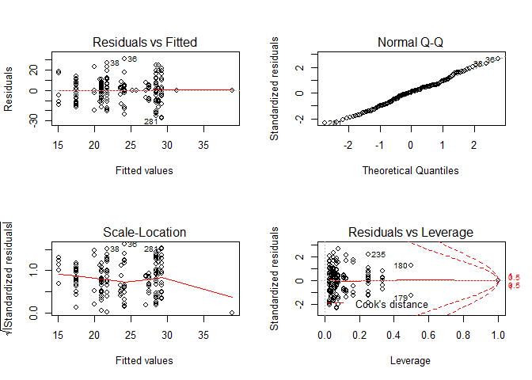

```r
par(mfrow=c(2,2))
plot(test0)
```

```r
summary(test0)
```

```
##
## Call:
## lm(formula = salinity..dS.m. ~ class, data = kssl.ec, contrasts = list(class = contr.treatment))
##
## Residuals:
##      Min       1Q   Median       3Q      Max
## -27.3881  -8.0439   0.1204   6.7575  30.8587
##
## Coefficients:
##             Estimate Std. Error t value Pr(>|t|)
## (Intercept) 23.71500    6.11496   3.878 0.000156 ***
## class2      -2.76622    6.83673  -0.405 0.686332
## class3      -2.73500    8.64786  -0.316 0.752236
## class4      -6.20577    6.56852  -0.945 0.346273
## class5       5.55307    6.93371   0.801 0.424451
## class6       5.14125    7.48926   0.686 0.493455
## class7       7.68500   13.67346   0.562 0.574918
## class8      -3.69250    8.64786  -0.427 0.669995
## class9       0.43089    6.99272   0.062 0.950946
## class10     -0.06379    9.34075  -0.007 0.994560
## class11     -1.97835    6.69860  -0.295 0.768139
## class12      1.53169   13.67346   0.112 0.910956
## class13      2.08500   13.67346   0.152 0.879007
## class14     15.28500   13.67346   1.118 0.265391
## class15     -2.71250    8.64786  -0.314 0.754208
## class16      3.42833    9.34075   0.367 0.714107
## class17      4.85019    6.48589   0.748 0.455732
## class18     -8.64167    7.89438  -1.095 0.275397
## class19     -2.96500   10.59142  -0.280 0.779901
## class20      3.80358    7.34926   0.518 0.605528
## ---
## Signif. codes:  0 '***' 0.001 '**' 0.01 '*' 0.05 '.' 0.1 ' ' 1
##
## Residual standard error: 12.23 on 152 degrees of freedom
## Multiple R-squared:  0.1381, Adjusted R-squared:  0.03041
## F-statistic: 1.282 on 19 and 152 DF,  p-value: 0.2027
```

```r
contr.treatment(unique(kssl.ec$class)) # for reference
```

```
##      sil vfsl lfs cosl cos sicl l sl cl fsl s fs ls l  s  sic scl vfs lcos
## si     0    0   0    0   0    0 0  0  0   0 0  0  0  0  0   0   0   0    0
## sil    1    0   0    0   0    0 0  0  0   0 0  0  0  0  0   0   0   0    0
## vfsl   0    1   0    0   0    0 0  0  0   0 0  0  0  0  0   0   0   0    0
## lfs    0    0   1    0   0    0 0  0  0   0 0  0  0  0  0   0   0   0    0
## cosl   0    0   0    1   0    0 0  0  0   0 0  0  0  0  0   0   0   0    0
## cos    0    0   0    0   1    0 0  0  0   0 0  0  0  0  0   0   0   0    0
## sicl   0    0   0    0   0    1 0  0  0   0 0  0  0  0  0   0   0   0    0
## l      0    0   0    0   0    0 1  0  0   0 0  0  0  0  0   0   0   0    0
## sl     0    0   0    0   0    0 0  1  0   0 0  0  0  0  0   0   0   0    0
## cl     0    0   0    0   0    0 0  0  1   0 0  0  0  0  0   0   0   0    0
## fsl    0    0   0    0   0    0 0  0  0   1 0  0  0  0  0   0   0   0    0
## s      0    0   0    0   0    0 0  0  0   0 1  0  0  0  0   0   0   0    0
## fs     0    0   0    0   0    0 0  0  0   0 0  1  0  0  0   0   0   0    0
## ls     0    0   0    0   0    0 0  0  0   0 0  0  1  0  0   0   0   0    0
## l      0    0   0    0   0    0 0  0  0   0 0  0  0  1  0   0   0   0    0
## s      0    0   0    0   0    0 0  0  0   0 0  0  0  0  1   0   0   0    0
## sic    0    0   0    0   0    0 0  0  0   0 0  0  0  0  0   1   0   0    0
## scl    0    0   0    0   0    0 0  0  0   0 0  0  0  0  0   0   1   0    0
## vfs    0    0   0    0   0    0 0  0  0   0 0  0  0  0  0   0   0   1    0
## lcos   0    0   0    0   0    0 0  0  0   0 0  0  0  0  0   0   0   0    1
```

# EC 1:5

## Scatterplot Matrix and Correlation Matrix

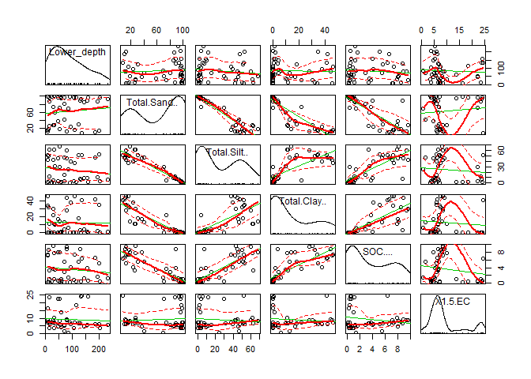

```r
spm(kssl.15ec.num)
```

```r
cor(kssl.15ec.num)
```

```
##              Lower_depth Total.Sand.. Total.Silt.. Total.Clay..    SOC....
## Lower_depth   1.00000000   0.09654223   -0.1385537  -0.02039577 -0.1072678
## Total.Sand..  0.09654223   1.00000000   -0.9526300  -0.90066317 -0.8515636
## Total.Silt.. -0.13855368  -0.95263000    1.0000000   0.72584806  0.8067869
## Total.Clay.. -0.02039577  -0.90066317    0.7258481   1.00000000  0.7733127
## SOC....      -0.10726781  -0.85156355    0.8067869   0.77331269  1.0000000
## X1.5.EC      -0.04984015   0.10149941   -0.1002209  -0.08637413 -0.1793993
##                  X1.5.EC
## Lower_depth  -0.04984015
## Total.Sand..  0.10149941
## Total.Silt.. -0.10022088
## Total.Clay.. -0.08637413
## SOC....      -0.17939925
## X1.5.EC       1.00000000
```

## ANOVA and Tukey Honest Significant Differences will be used to evaluate texture class and EC 1:5

```r
amod2 <- aov(X1.5.EC ~ class, data=kssl.15ec)
amod2
```

```
## Call:
##    aov(formula = X1.5.EC ~ class, data = kssl.15ec)
##
## Terms:
##                     class Residuals
## Sum of Squares   465.7749 1389.2154
## Deg. of Freedom        12        30
##
## Residual standard error: 6.804938
## Estimated effects may be unbalanced
```

```r
summary(amod2)
```

```
##             Df Sum Sq Mean Sq F value Pr(>F)
## class       12  465.8   38.81   0.838  0.613
## Residuals   30 1389.2   46.31
```

```r
print(model.tables(amod2, "effects", se = TRUE))
```

```
## Design is unbalanced - use se.contrast() for se's
```

```
## Tables of effects
##
##  class
##         cl    cos    fs   fsl      l   lfs    ls      s   scl   sic   sicl
##     -1.155 -1.893 5.763 -2.43 -6.025 -3.71 -4.44 0.4878 -2.21 2.965 -2.217
## rep  4.000  7.000 7.000  1.00  2.000  2.00  1.00 5.0000  1.00 4.000  3.000
##        sil   sl
##     -1.575 2.37
## rep  4.000 2.00
```

```r
tukey2 <- TukeyHSD(amod2, "class")
ec15.hsd.table <- as.data.frame(tukey2$class)
ec15.hsd.table[ order(ec15.hsd.table$`p adj`), ]
```

```
##                   diff        lwr       upr     p adj
## l-fs     -11.787857143 -31.375150  7.799436 0.6241079
## fs-cos     7.655714286  -5.402481 20.713910 0.6599034
## lfs-fs    -9.472857143 -29.060150 10.114436 0.8642255
## sil-fs    -7.337857143 -22.649948  7.974234 0.8710366
## sicl-fs   -7.979523810 -24.837581  8.878534 0.8798300
## fs-cl      6.917857143  -8.394234 22.229948 0.9089520
## sic-l      8.990000000 -12.166694 30.146694 0.9384495
## ls-fs    -10.202857143 -36.319248 15.913533 0.9656455
## s-fs      -5.274857143 -19.579393  9.029679 0.9776470
## sl-l       8.395000000 -16.034646 32.824646 0.9871708
## s-l        6.513000000 -13.926309 26.952309 0.9931561
## sic-cos    4.857857143 -10.454234 20.169948 0.9934081
## sic-lfs    6.675000000 -14.481694 27.831694 0.9937143
## fsl-fs    -8.192857143 -34.309248 17.923533 0.9940162
## scl-fs    -7.972857143 -34.089248 18.143533 0.9952786
## sicl-sic  -5.181666667 -23.840117 13.476784 0.9979898
## sic-ls     7.405000000 -19.908175 34.718175 0.9983929
## sil-sic   -4.540000000 -21.814369 12.734369 0.9988013
## sl-lfs     6.080000000 -18.349646 30.509646 0.9992903
## sic-cl     4.120000000 -13.154369 21.394369 0.9995327
## l-cl      -4.870000000 -26.026694 16.286694 0.9996718
## sl-ls      6.810000000 -23.110084 36.730084 0.9997070
## sl-cos     4.262857143 -15.324436 23.850150 0.9998139
## l-cos     -4.132142857 -23.719436 15.455150 0.9998648
## sil-l      4.450000000 -16.706694 25.606694 0.9998689
## sl-sicl    4.586666667 -17.714447 26.887781 0.9998961
## s-lfs      4.198000000 -16.241309 24.637309 0.9998976
## sic-fsl    5.395000000 -21.918175 32.708175 0.9999319
## sic-scl    5.175000000 -22.138175 32.488175 0.9999561
## sl-sil     3.945000000 -17.211694 25.101694 0.9999630
## s-ls       4.928000000 -21.833337 31.689337 0.9999676
## sic-fs    -2.797857143 -18.109948 12.514234 0.9999702
## sl-fs     -3.392857143 -22.980150 16.194436 0.9999832
## sicl-l     3.808333333 -18.492781 26.109447 0.9999856
## sl-cl      3.525000000 -17.631694 24.681694 0.9999890
## s-cos      2.380857143 -11.923679 16.685393 0.9999891
## sl-fsl     4.800000000 -25.120084 34.720084 0.9999927
## sl-scl     4.580000000 -25.340084 34.500084 0.9999957
## sicl-s    -2.704666667 -20.545558 15.136224 0.9999961
```

[output cut: 24 more lines]

```
## lfs-fsl   -1.280000000 -31.200084 28.640084 1.0000000
## scl-cl    -1.055000000 -28.368175 26.258175 1.0000000
## sil-cl    -0.420000000 -17.694369 16.854369 1.0000000
## fsl-cos   -0.537142857 -26.653533 25.579248 1.0000000
## scl-cos   -0.317142857 -26.433533 25.799248 1.0000000
## sicl-cos  -0.323809524 -17.181867 16.534248 1.0000000
## sil-cos    0.317857143 -14.994234 15.629948 1.0000000
## scl-fsl    0.220000000 -34.328737 34.768737 1.0000000
## sicl-fsl   0.213333333 -27.995592 28.422259 1.0000000
## sil-fsl    0.855000000 -26.458175 28.168175 1.0000000
## ls-lfs    -0.730000000 -30.650084 29.190084 1.0000000
## sicl-scl  -0.006666667 -28.215592 28.202259 1.0000000
## sil-scl    0.635000000 -26.678175 27.948175 1.0000000
## sl-sic    -0.595000000 -21.751694 20.561694 1.0000000
## sil-sicl   0.641666667 -18.016784 19.300117 1.0000000
```

```r
#write.csv(ec15.hsd.table, file="ec15.hsdtable.csv", row.names = TRUE)

# standard error table
test1 <- lm(X1.5.EC ~ class, data=kssl.15ec, contrasts = list(class = contr.treatment))
anova(test1)
```

```
## Analysis of Variance Table
##
## Response: X1.5.EC
##           Df  Sum Sq Mean Sq F value Pr(>F)
## class     12  465.77  38.815  0.8382 0.6127
## Residuals 30 1389.22  46.307
```

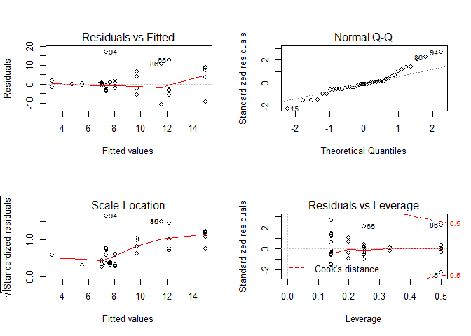

```r
par(mfrow=c(2,2))
plot(test1)
```

```r
summary(test1)
```

```
##
## Call:
## lm(formula = X1.5.EC ~ class, data = kssl.15ec, contrasts = list(class = contr.treatment))
##
## Residuals:
##     Min      1Q  Median      3Q     Max
## -10.810  -3.131  -0.605   1.270  16.873
##
## Coefficients:
##             Estimate Std. Error t value Pr(>|t|)
## (Intercept)   8.0650     3.4025   2.370   0.0244 *
## class2       -0.7379     4.2652  -0.173   0.8638
## class3        6.9179     4.2652   1.622   0.1153
## class4       -1.2750     7.6082  -0.168   0.8680
## class5       -4.8700     5.8932  -0.826   0.4151
## class6       -2.5550     5.8932  -0.434   0.6677
## class7       -3.2850     7.6082  -0.432   0.6690
## class8        1.6430     4.5649   0.360   0.7214
## class9       -1.0550     7.6082  -0.139   0.8906
## class10       4.1200     4.8118   0.856   0.3987
## class11      -1.0617     5.1974  -0.204   0.8395
## class12      -0.4200     4.8118  -0.087   0.9310
## class13       3.5250     5.8932   0.598   0.5542
## ---
## Signif. codes:  0 '***' 0.001 '**' 0.01 '*' 0.05 '.' 0.1 ' ' 1
##
## Residual standard error: 6.805 on 30 degrees of freedom
## Multiple R-squared:  0.2511, Adjusted R-squared:  -0.04847
## F-statistic: 0.8382 on 12 and 30 DF,  p-value: 0.6127
```

```r
contr.treatment(unique(kssl.15ec$class)) # for reference
```

```
##      l sl sil cl lfs fsl sic scl cos ls fs s
## sicl 0  0   0  0   0   0   0   0   0  0  0 0
## l    1  0   0  0   0   0   0   0   0  0  0 0
## sl   0  1   0  0   0   0   0   0   0  0  0 0
## sil  0  0   1  0   0   0   0   0   0  0  0 0
## cl   0  0   0  1   0   0   0   0   0  0  0 0
## lfs  0  0   0  0   1   0   0   0   0  0  0 0
## fsl  0  0   0  0   0   1   0   0   0  0  0 0
## sic  0  0   0  0   0   0   1   0   0  0  0 0
## scl  0  0   0  0   0   0   0   1   0  0  0 0
## cos  0  0   0  0   0   0   0   0   1  0  0 0
## ls   0  0   0  0   0   0   0   0   0  1  0 0
## fs   0  0   0  0   0   0   0   0   0  0  1 0
## s    0  0   0  0   0   0   0   0   0  0  0 1
```

# Discussion

Given the data available, there do not appear to be significant differences in EC data based on sand, silt, or clay content, horizon depth, or organic carbon content.

5th percentile, Median, and 95th percentile values will be used for populating aggregate Component Horizon data regardless of depth, texture/PSA, or OM% data

```r
# EC summary
length(kssl.ec.num$salinity..dS.m.)
```

```
## [1] 172
```

```r
quantile(kssl.ec.num$salinity..dS.m., probs= c(.05, .95))
```

```
##       5%      95%
##  2.76300 46.62532
```

```r
median(kssl.ec.num$salinity..dS.m.)
```

```
## [1] 25.17335
```

## EC CHorizon values

| L | RV | H |
| --- | --- | --- |
| 2 | 25 | 47 |

```r
# EC 1:5 summary
length(kssl.15ec.num$X1.5.EC)
```

```
## [1] 43
```

```r
quantile(kssl.15ec.num$X1.5.EC, probs= c(.05, .95))
```

```
##     5%    95%
##  3.631 23.850
```

```r
median(kssl.15ec.num$X1.5.EC)
```

```
## [1] 6.94
```

## EC 1:5 CHorizon values

| L | RV | H |
| --- | --- | --- |
| 4 | 7 | 24 |

# Exploration of EC ~ PHorizon Color Chroma

```r
library(soilDB)
#Query known SAS KSSL pedons for color data

URI0603GB <- fetchKSSL(pedlabsampnum = 'URI0603GB', returnMorphologicData= TRUE)
```

```
## 1 pedons loaded (0.03 Mb transferred)
```

```r
URI0604GB <- fetchKSSL(pedlabsampnum = 'URI0604GB', returnMorphologicData= TRUE)
```

```
## 1 pedons loaded (0.03 Mb transferred)
```

```r
URI0605GB <- fetchKSSL(pedlabsampnum = 'URI0605GB', returnMorphologicData= TRUE)
```

```
## 1 pedons loaded (0.03 Mb transferred)
```

```r
URI0607GB <- fetchKSSL(pedlabsampnum = 'URI0607GB', returnMorphologicData= TRUE)
```

```
## 1 pedons loaded (0.03 Mb transferred)
```

```r
URI0608GB <- fetchKSSL(pedlabsampnum = 'URI0608GB', returnMorphologicData= TRUE)
```

```
## 1 pedons loaded (0.03 Mb transferred)
```

```r
URI0001NP <- fetchKSSL(pedlabsampnum = 'URI0001NP', returnMorphologicData= TRUE)
```

```
## 1 pedons loaded (0.02 Mb transferred)
```

```r
URI0002NP <- fetchKSSL(pedlabsampnum = 'URI0002NP', returnMorphologicData= TRUE)
```

```
## 1 pedons loaded (0.02 Mb transferred)
```

```r
URI0003NP <- fetchKSSL(pedlabsampnum = 'URI0003NP', returnMorphologicData= TRUE)
```

```
## 1 pedons loaded (0.02 Mb transferred)
```

```r
URI0004NP <- fetchKSSL(pedlabsampnum = 'URI0004NP', returnMorphologicData= TRUE)
```

```
## 1 pedons loaded (0.02 Mb transferred)
```

```r
URI0005NP <- fetchKSSL(pedlabsampnum = 'URI0005NP', returnMorphologicData= TRUE)
```

```
## 1 pedons loaded (0.02 Mb transferred)
```

```r
URI0006NP <- fetchKSSL(pedlabsampnum = 'URI0006NP', returnMorphologicData= TRUE)
```

```
## 1 pedons loaded (0.02 Mb transferred)
```

```r
URI0007NP <- fetchKSSL(pedlabsampnum = 'URI0007NP', returnMorphologicData= TRUE)
```

```
## 1 pedons loaded (0.02 Mb transferred)
```

```r
URI0008NP <- fetchKSSL(pedlabsampnum = 'URI0008NP', returnMorphologicData= TRUE)
```

```
## 1 pedons loaded (0.02 Mb transferred)
```

```r
URI0009NP <- fetchKSSL(pedlabsampnum = 'URI0009NP', returnMorphologicData= TRUE)
```

```
## 1 pedons loaded (0.02 Mb transferred)
```

```r
URI0404NP <- fetchKSSL(pedlabsampnum = 'URI0404NP', returnMorphologicData= TRUE)
```

```
## 1 pedons loaded (0.03 Mb transferred)
```

```r
URI0606WH <- fetchKSSL(pedlabsampnum = 'URI0606WH', returnMorphologicData= TRUE)
```

```
## 1 pedons loaded (0.02 Mb transferred)
```

```r
URI0607WH <- fetchKSSL(pedlabsampnum = 'URI0607WH', returnMorphologicData= TRUE)
```

```
## 1 pedons loaded (0.02 Mb transferred)
```

```r
URI0608WH <- fetchKSSL(pedlabsampnum = 'URI0608WH', returnMorphologicData= TRUE)
```

```
## 1 pedons loaded (0.02 Mb transferred)
```

```r
URI0609WH <- fetchKSSL(pedlabsampnum = 'URI0609WH', returnMorphologicData= TRUE)
```

```
## 1 pedons loaded (0.03 Mb transferred)
```

```r
URI0610QP <- fetchKSSL(pedlabsampnum = 'URI0610QP', returnMorphologicData= TRUE)
```

```
## 1 pedons loaded (0.03 Mb transferred)
```

```r
URI0611QP <- fetchKSSL(pedlabsampnum = 'URI0611QP', returnMorphologicData= TRUE)
```

```
## 1 pedons loaded (0.03 Mb transferred)
```

```r
URI0612QP <- fetchKSSL(pedlabsampnum = 'URI0612QP', returnMorphologicData= TRUE)
```

```
## 1 pedons loaded (0.03 Mb transferred)
```

```r
URI0613QP <- fetchKSSL(pedlabsampnum = 'URI0613QP', returnMorphologicData= TRUE)
```

```
## 1 pedons loaded (0.03 Mb transferred)
```

```r
URI0614QP <- fetchKSSL(pedlabsampnum = 'URI0614QP', returnMorphologicData= TRUE)
```

```
## 1 pedons loaded (0.03 Mb transferred)
```

```r
URI0615QP <- fetchKSSL(pedlabsampnum = 'URI0615QP', returnMorphologicData= TRUE)
```

```
## 1 pedons loaded (0.03 Mb transferred)
```

```r
URI0705PJ <- fetchKSSL(pedlabsampnum = 'URI0705PJ', returnMorphologicData= TRUE)
```

```
## 1 pedons loaded (0.03 Mb transferred)
```

```r
URI0706PJ <- fetchKSSL(pedlabsampnum = 'URI0706PJ', returnMorphologicData= TRUE)
```

```
## 1 pedons loaded (0.03 Mb transferred)
```

```r
URI0707PJ <- fetchKSSL(pedlabsampnum = 'URI0707PJ', returnMorphologicData= TRUE)
```

```
## 1 pedons loaded (0.03 Mb transferred)
```

```r
URI0708PJ <- fetchKSSL(pedlabsampnum = 'URI0708PJ', returnMorphologicData= TRUE)
```

```
## 1 pedons loaded (0.03 Mb transferred)
```

```r
URI0710PJ <- fetchKSSL(pedlabsampnum = 'URI0710PJ', returnMorphologicData= TRUE)
```

```
## 1 pedons loaded (0.03 Mb transferred)
```

```r
URI0711PJ <- fetchKSSL(pedlabsampnum = 'URI0711PJ', returnMorphologicData= TRUE)
```

```
## 1 pedons loaded (0.03 Mb transferred)
```

```r
URI0712PJ <- fetchKSSL(pedlabsampnum = 'URI0712PJ', returnMorphologicData= TRUE)
```

```
## 1 pedons loaded (0.03 Mb transferred)
```

```r
URI0713PJ <- fetchKSSL(pedlabsampnum = 'URI0713PJ', returnMorphologicData= TRUE)
```

```
## 1 pedons loaded (0.03 Mb transferred)
```

```r
URI0714PJ <- fetchKSSL(pedlabsampnum = 'URI0714PJ', returnMorphologicData= TRUE)
```

```
## 1 pedons loaded (0.03 Mb transferred)
```

```r
URI0801NP <- fetchKSSL(pedlabsampnum = 'URI0801NP', returnMorphologicData= TRUE)
```

```
## 1 pedons loaded (0.03 Mb transferred)
```

```r
URI0802NP <- fetchKSSL(pedlabsampnum = 'URI0802NP', returnMorphologicData= TRUE)
```

```
## 1 pedons loaded (0.03 Mb transferred)
```

```r
URI0803NP <- fetchKSSL(pedlabsampnum = 'URI0803NP', returnMorphologicData= TRUE)
```

```
## 1 pedons loaded (0.03 Mb transferred)
```

```r
URI0804NP <- fetchKSSL(pedlabsampnum = 'URI0804NP', returnMorphologicData= TRUE)
```

```
## 1 pedons loaded (0.02 Mb transferred)
```

```r
URI0805NP <- fetchKSSL(pedlabsampnum = 'URI0805NP', returnMorphologicData= TRUE)
```

```
## 1 pedons loaded (0.03 Mb transferred)
```

```r
URI0806NP <- fetchKSSL(pedlabsampnum = 'URI0806NP', returnMorphologicData= TRUE)
```

```
## 1 pedons loaded (0.03 Mb transferred)
```

```r
URI0807NP <- fetchKSSL(pedlabsampnum = 'URI0807NP', returnMorphologicData= TRUE)
```

```
## 1 pedons loaded (0.03 Mb transferred)
```

```r
URI0808NP <- fetchKSSL(pedlabsampnum = 'URI0808NP', returnMorphologicData= TRUE)
```

```
## 1 pedons loaded (0.03 Mb transferred)
```

```r
URI0809NP <- fetchKSSL(pedlabsampnum = 'URI0809NP', returnMorphologicData= TRUE)
```

```
## 1 pedons loaded (0.03 Mb transferred)
```

```r
URI0810NP <- fetchKSSL(pedlabsampnum = 'URI0810NP', returnMorphologicData= TRUE)
```

```
## 1 pedons loaded (0.03 Mb transferred)
```

```r
URI0811QP <- fetchKSSL(pedlabsampnum = 'URI0811QP', returnMorphologicData= TRUE)
```

```
## 1 pedons loaded (0.03 Mb transferred)
```

```r
URI0812QP <- fetchKSSL(pedlabsampnum = 'URI0812QP', returnMorphologicData= TRUE)
```

```
## 1 pedons loaded (0.03 Mb transferred)
```

```r
URI0813QP <- fetchKSSL(pedlabsampnum = 'URI0813QP', returnMorphologicData= TRUE)
```

```
## 1 pedons loaded (0.03 Mb transferred)
```

```r
URI0901QP <- fetchKSSL(pedlabsampnum = 'URI0901QP', returnMorphologicData= TRUE)
```

```
## 1 pedons loaded (0.03 Mb transferred)
```

```r
URI0902QP <- fetchKSSL(pedlabsampnum = 'URI0902QP', returnMorphologicData= TRUE)
```

```
## 1 pedons loaded (0.03 Mb transferred)
```

```r
URI0903QP <- fetchKSSL(pedlabsampnum = 'URI0903QP', returnMorphologicData= TRUE)
```

```
## 1 pedons loaded (0.03 Mb transferred)
```

```r
URI0904QP <- fetchKSSL(pedlabsampnum = 'URI0904QP', returnMorphologicData= TRUE)
```

```
## 1 pedons loaded (0.03 Mb transferred)
```

```r
URI0905QP <- fetchKSSL(pedlabsampnum = 'URI0905QP', returnMorphologicData= TRUE)
```

```
## 1 pedons loaded (0.03 Mb transferred)
```

```r
URI0906QP <- fetchKSSL(pedlabsampnum = 'URI0906QP', returnMorphologicData= TRUE)
```

```
## 1 pedons loaded (0.03 Mb transferred)
```

```r
URI0907PJ <- fetchKSSL(pedlabsampnum = 'URI0907PJ', returnMorphologicData= TRUE)
```

```
## 1 pedons loaded (0.03 Mb transferred)
```

```r
URI0908PJ <- fetchKSSL(pedlabsampnum = 'URI0908PJ', returnMorphologicData= TRUE)
```

```
## 1 pedons loaded (0.03 Mb transferred)
```

```r
URI0909PJ <- fetchKSSL(pedlabsampnum = 'URI0909PJ', returnMorphologicData= TRUE)
```

```
## 1 pedons loaded (0.03 Mb transferred)
```

```r
URI0911PJ <- fetchKSSL(pedlabsampnum = 'URI0911PJ', returnMorphologicData= TRUE)
```

```
## 1 pedons loaded (0.03 Mb transferred)
```

```r
URI0912PJ <- fetchKSSL(pedlabsampnum = 'URI0912PJ', returnMorphologicData= TRUE)
```

```
## 1 pedons loaded (0.03 Mb transferred)
```

```r
URI0913PJ <- fetchKSSL(pedlabsampnum = 'URI0913PJ', returnMorphologicData= TRUE)
```

```
## 1 pedons loaded (0.03 Mb transferred)
```

```r
URI0916NP <- fetchKSSL(pedlabsampnum = 'URI0916NP', returnMorphologicData= TRUE)
```

```
## 1 pedons loaded (0.03 Mb transferred)
```

```r
URI0917NP <- fetchKSSL(pedlabsampnum = 'URI0917NP', returnMorphologicData= TRUE)
```

```
## 1 pedons loaded (0.03 Mb transferred)
```

```r
URI0918NP <- fetchKSSL(pedlabsampnum = 'URI0918NP', returnMorphologicData= TRUE)
```

```
## 1 pedons loaded (0.03 Mb transferred)
```

```r
URI0919NP <- fetchKSSL(pedlabsampnum = 'URI0919NP', returnMorphologicData= TRUE)
```

```
## 1 pedons loaded (0.03 Mb transferred)
```

```r
#URI0506NP <- fetchKSSL(pedlabsampnum = 'URI0506NP', returnMorphologicData= TRUE)
#URI0511NP <- fetchKSSL(pedlabsampnum = 'URI0511NP', returnMorphologicData= TRUE)
#URI0512NP <- fetchKSSL(pedlabsampnum = 'URI0512NP', returnMorphologicData= TRUE)
#URI0603WH <- fetchKSSL(pedlabsampnum = 'URI0603WH', returnMorphologicData= TRUE)
#URI0604WH <- fetchKSSL(pedlabsampnum = 'URI0604WH', returnMorphologicData= TRUE)
#URI0605WH <- fetchKSSL(pedlabsampnum = 'URI0605WH', returnMorphologicData= TRUE)
#URI0616QP <- fetchKSSL(pedlabsampnum = 'URI0616QP', returnMorphologicData= TRUE)
#URI0617QP <- fetchKSSL(pedlabsampnum = 'URI0617QP', returnMorphologicData= TRUE)
#URI0618QP <- fetchKSSL(pedlabsampnum = 'URI0618QP', returnMorphologicData= TRUE)
#URI0701QP <- fetchKSSL(pedlabsampnum = 'URI0701QP', returnMorphologicData= TRUE)
#URI0702QP <- fetchKSSL(pedlabsampnum = 'URI0702QP', returnMorphologicData= TRUE)
#URI0703QP <- fetchKSSL(pedlabsampnum = 'URI0703QP', returnMorphologicData= TRUE)
#URI0704QP <- fetchKSSL(pedlabsampnum = 'URI0704QP', returnMorphologicData= TRUE)
#URI0814WP <- fetchKSSL(pedlabsampnum = 'URI0814WP', returnMorphologicData= TRUE)
#URI0815WP <- fetchKSSL(pedlabsampnum = 'URI0815WP', returnMorphologicData= TRUE)
#URI0817WP <- fetchKSSL(pedlabsampnum = 'URI0817WP', returnMorphologicData= TRUE)
#URI0818WP <- fetchKSSL(pedlabsampnum = 'URI0818WP', returnMorphologicData= TRUE)
#URI0819WP <- fetchKSSL(pedlabsampnum = 'URI0819WP', returnMorphologicData= TRUE)
#URI0820WP <- fetchKSSL(pedlabsampnum = 'URI0820WP', returnMorphologicData= TRUE)
#URI0914PJ <- fetchKSSL(pedlabsampnum = 'URI0914PJ', returnMorphologicData= TRUE)
#URI0915PJ <- fetchKSSL(pedlabsampnum = 'URI0915PJ', returnMorphologicData= TRUE)
URI130301 <- fetchKSSL(pedlabsampnum = 'URI130301', returnMorphologicData= TRUE)
```

```
## 1 pedons loaded (0.03 Mb transferred)
```

```r
URI130302 <- fetchKSSL(pedlabsampnum = 'URI130302', returnMorphologicData= TRUE)
```

```
## 1 pedons loaded (0.03 Mb transferred)
```

```r
URI130702 <- fetchKSSL(pedlabsampnum = 'URI130702', returnMorphologicData= TRUE)
```

```
## 1 pedons loaded (0.03 Mb transferred)
```

```r
URI130901 <- fetchKSSL(pedlabsampnum = 'URI130901', returnMorphologicData= TRUE)
```

```
## 1 pedons loaded (0.02 Mb transferred)
```

```r
URI130902 <- fetchKSSL(pedlabsampnum = 'URI130902', returnMorphologicData= TRUE)
```

```
## 1 pedons loaded (0.03 Mb transferred)
```

```r
URI130903 <- fetchKSSL(pedlabsampnum = 'URI130903', returnMorphologicData= TRUE)
```

```
## 1 pedons loaded (0.03 Mb transferred)
```

```r
URI130904 <- fetchKSSL(pedlabsampnum = 'URI130904', returnMorphologicData= TRUE)
```

```
## 1 pedons loaded (0.03 Mb transferred)
```

```r
URI130905 <- fetchKSSL(pedlabsampnum = 'URI130905', returnMorphologicData= TRUE)
```

```
## 1 pedons loaded (0.02 Mb transferred)
```

```r
URI130906 <- fetchKSSL(pedlabsampnum = 'URI130906', returnMorphologicData= TRUE)
```

```
## 1 pedons loaded (0.02 Mb transferred)
```

```r
URI130907 <- fetchKSSL(pedlabsampnum = 'URI130907', returnMorphologicData= TRUE)
```

```
## 1 pedons loaded (0.03 Mb transferred)
```

```r
URI130908 <- fetchKSSL(pedlabsampnum = 'URI130908', returnMorphologicData= TRUE)
```

```
## 1 pedons loaded (0.03 Mb transferred)
```

```r
URI130909 <- fetchKSSL(pedlabsampnum = 'URI130909', returnMorphologicData= TRUE)
```

```
## 1 pedons loaded (0.03 Mb transferred)
```

```r
URI130910 <- fetchKSSL(pedlabsampnum = 'URI130910', returnMorphologicData= TRUE)
```

```
## 1 pedons loaded (0.03 Mb transferred)
```

```r
URI130911 <- fetchKSSL(pedlabsampnum = 'URI130911', returnMorphologicData= TRUE)
```

```
## 1 pedons loaded (0.03 Mb transferred)
```

```r
URI130912 <- fetchKSSL(pedlabsampnum = 'URI130912', returnMorphologicData= TRUE)
```

```
## 1 pedons loaded (0.03 Mb transferred)
```

```r
URI130913 <- fetchKSSL(pedlabsampnum = 'URI130913', returnMorphologicData= TRUE)
```

```
## 1 pedons loaded (0.03 Mb transferred)
```

```r
URI130914 <- fetchKSSL(pedlabsampnum = 'URI130914', returnMorphologicData= TRUE)
```

```
## 1 pedons loaded (0.03 Mb transferred)
```

```r
URI130915 <- fetchKSSL(pedlabsampnum = 'URI130915', returnMorphologicData= TRUE)
```

```
## 1 pedons loaded (0.03 Mb transferred)
```

```r
URI130916 <- fetchKSSL(pedlabsampnum = 'URI130916', returnMorphologicData= TRUE)
```

```
## 1 pedons loaded (0.03 Mb transferred)
```

```r
URI130917 <- fetchKSSL(pedlabsampnum = 'URI130917', returnMorphologicData= TRUE)
```

```
## 1 pedons loaded (0.03 Mb transferred)
```

```r
URI130918 <- fetchKSSL(pedlabsampnum = 'URI130918', returnMorphologicData= TRUE)
```

```
## 1 pedons loaded (0.03 Mb transferred)
```

```r
URI130919 <- fetchKSSL(pedlabsampnum = 'URI130919', returnMorphologicData= TRUE)
```

```
## 1 pedons loaded (0.03 Mb transferred)
```

```r
URI130920 <- fetchKSSL(pedlabsampnum = 'URI130920', returnMorphologicData= TRUE)
```

```
## 1 pedons loaded (0.03 Mb transferred)
```

```r
URI130921 <- fetchKSSL(pedlabsampnum = 'URI130921', returnMorphologicData= TRUE)
```

```
## 1 pedons loaded (0.03 Mb transferred)
```

```r
URI130922 <- fetchKSSL(pedlabsampnum = 'URI130922', returnMorphologicData= TRUE)
```

```
## 1 pedons loaded (0.03 Mb transferred)
```

```r
URI130923 <- fetchKSSL(pedlabsampnum = 'URI130923', returnMorphologicData= TRUE)
```

```
## 1 pedons loaded (0.03 Mb transferred)
```

```r
URI130924 <- fetchKSSL(pedlabsampnum = 'URI130924', returnMorphologicData= TRUE)
```

```
## 1 pedons loaded (0.03 Mb transferred)
```

```r
URI0001 <- fetchKSSL(pedlabsampnum = 'URI0001', returnMorphologicData= TRUE)
```

```
## 1 pedons loaded (0.02 Mb transferred)
```

```r
URI0002 <- fetchKSSL(pedlabsampnum = 'URI0002', returnMorphologicData= TRUE)
```

```
## 1 pedons loaded (0.03 Mb transferred)
```

```r
URI0003 <- fetchKSSL(pedlabsampnum = 'URI0003', returnMorphologicData= TRUE)
```

```
## 1 pedons loaded (0.03 Mb transferred)
```

```r
URI0004 <- fetchKSSL(pedlabsampnum = 'URI0004', returnMorphologicData= TRUE)
```

```
## 1 pedons loaded (0.02 Mb transferred)
```

```r
URI0005 <- fetchKSSL(pedlabsampnum = 'URI0005', returnMorphologicData= TRUE)
```

```
## 1 pedons loaded (0.02 Mb transferred)
```

```r
URI0006 <- fetchKSSL(pedlabsampnum = 'URI0006', returnMorphologicData= TRUE)
```

```
## 1 pedons loaded (0.03 Mb transferred)
```

```r
URI0007 <- fetchKSSL(pedlabsampnum = 'URI0007', returnMorphologicData= TRUE)
```

```
## 1 pedons loaded (0.03 Mb transferred)
```

```r
URI0008 <- fetchKSSL(pedlabsampnum = 'URI0008', returnMorphologicData= TRUE)
```

```
## 1 pedons loaded (0.03 Mb transferred)
```

```r
URI0603GB.color <- URI0603GB$morph$phcolor
URI0604GB.color <- URI0604GB$morph$phcolor
URI0605GB.color <- URI0605GB$morph$phcolor
URI0607GB.color <- URI0607GB$morph$phcolor
URI0608GB.color <- URI0608GB$morph$phcolor
URI0001NP.color <- URI0001NP$morph$phcolor
URI0002NP.color <- URI0002NP$morph$phcolor
URI0003NP.color <- URI0003NP$morph$phcolor
URI0004NP.color <- URI0004NP$morph$phcolor
URI0005NP.color <- URI0005NP$morph$phcolor
URI0006NP.color <- URI0006NP$morph$phcolor
URI0007NP.color <- URI0007NP$morph$phcolor
URI0008NP.color <- URI0008NP$morph$phcolor
URI0009NP.color <- URI0009NP$morph$phcolor
URI0404NP.color <- URI0404NP$morph$phcolor
URI0606WH.color <- URI0606WH$morph$phcolor
URI0607WH.color <- URI0607WH$morph$phcolor
URI0608WH.color <- URI0608WH$morph$phcolor
URI0609WH.color <- URI0609WH$morph$phcolor
URI0610QP.color <- URI0610QP$morph$phcolor
URI0611QP.color <- URI0611QP$morph$phcolor
URI0612QP.color <- URI0612QP$morph$phcolor
URI0613QP.color <- URI0613QP$morph$phcolor
URI0614QP.color <- URI0614QP$morph$phcolor
URI0615QP.color <- URI0615QP$morph$phcolor
URI0705PJ.color <- URI0705PJ$morph$phcolor
URI0706PJ.color <- URI0706PJ$morph$phcolor
URI0707PJ.color <- URI0707PJ$morph$phcolor
URI0708PJ.color <- URI0708PJ$morph$phcolor
URI0710PJ.color <- URI0710PJ$morph$phcolor
URI0711PJ.color <- URI0711PJ$morph$phcolor
URI0712PJ.color <- URI0712PJ$morph$phcolor
URI0713PJ.color <- URI0713PJ$morph$phcolor
URI0714PJ.color <- URI0714PJ$morph$phcolor
URI0801NP.color <- URI0801NP$morph$phcolor
URI0802NP.color <- URI0802NP$morph$phcolor
URI0803NP.color <- URI0803NP$morph$phcolor
URI0804NP.color <- URI0804NP$morph$phcolor
URI0805NP.color <- URI0805NP$morph$phcolor
URI0806NP.color <- URI0806NP$morph$phcolor
URI0807NP.color <- URI0807NP$morph$phcolor
URI0808NP.color <- URI0808NP$morph$phcolor
URI0809NP.color <- URI0809NP$morph$phcolor
URI0810NP.color <- URI0810NP$morph$phcolor
URI0811QP.color <- URI0811QP$morph$phcolor
URI0812QP.color <- URI0812QP$morph$phcolor
URI0813QP.color <- URI0813QP$morph$phcolor
URI0901QP.color <- URI0901QP$morph$phcolor
URI0902QP.color <- URI0902QP$morph$phcolor
URI0903QP.color <- URI0903QP$morph$phcolor
URI0904QP.color <- URI0904QP$morph$phcolor
URI0905QP.color <- URI0905QP$morph$phcolor
URI0906QP.color <- URI0906QP$morph$phcolor
URI0907PJ.color <- URI0907PJ$morph$phcolor
URI0908PJ.color <- URI0908PJ$morph$phcolor
URI0909PJ.color <- URI0909PJ$morph$phcolor
URI0911PJ.color <- URI0911PJ$morph$phcolor
URI0912PJ.color <- URI0912PJ$morph$phcolor
URI0913PJ.color <- URI0913PJ$morph$phcolor
URI0916NP.color <- URI0916NP$morph$phcolor
URI0917NP.color <- URI0917NP$morph$phcolor
URI0918NP.color <- URI0918NP$morph$phcolor
URI0919NP.color <- URI0919NP$morph$phcolor
#URI0506NP.color <- URI0506NP$morph$phcolor
#URI0511NP.color <- URI0511NP$morph$phcolor
#URI0512NP.color <- URI0512NP$morph$phcolor
#URI0603WH.color <- URI0603WH$morph$phcolor
#URI0604WH.color <- URI0604WH$morph$phcolor
#URI0605WH.color <- URI0605WH$morph$phcolor
#URI0616QP.color <- URI0616QP$morph$phcolor
#URI0617QP.color <- URI0617QP$morph$phcolor
#URI0618QP.color <- URI0618QP$morph$phcolor
#URI0701QP.color <- URI0701QP$morph$phcolor
#URI0702QP.color <- URI0702QP$morph$phcolor
#URI0703QP.color <- URI0703QP$morph$phcolor
#URI0704QP.color <- URI0704QP$morph$phcolor
#URI0814WP.color <- URI0814WP$morph$phcolor
#URI0815WP.color <- URI0815WP$morph$phcolor
#URI0817WP.color <- URI0817WP$morph$phcolor
#URI0818WP.color <- URI0818WP$morph$phcolor
#URI0819WP.color <- URI0819WP$morph$phcolor
#URI0820WP.color <- URI0820WP$morph$phcolor
#URI0914PJ.color <- URI0914PJ$morph$phcolor
#URI0915PJ.color <- URI0915PJ$morph$phcolor
URI130301.color <- URI130301$morph$phcolor
URI130302.color <- URI130302$morph$phcolor
URI130702.color <- URI130702$morph$phcolor
URI130901.color <- URI130901$morph$phcolor
URI130902.color <- URI130902$morph$phcolor
URI130903.color <- URI130903$morph$phcolor
URI130904.color <- URI130904$morph$phcolor
URI130905.color <- URI130905$morph$phcolor
URI130906.color <- URI130906$morph$phcolor
URI130907.color <- URI130907$morph$phcolor
URI130908.color <- URI130908$morph$phcolor
URI130909.color <- URI130909$morph$phcolor
URI130910.color <- URI130910$morph$phcolor
URI130911.color <- URI130911$morph$phcolor
URI130912.color <- URI130912$morph$phcolor
URI130913.color <- URI130913$morph$phcolor
URI130914.color <- URI130914$morph$phcolor
URI130915.color <- URI130915$morph$phcolor
URI130916.color <- URI130916$morph$phcolor
URI130917.color <- URI130917$morph$phcolor
URI130918.color <- URI130918$morph$phcolor
URI130919.color <- URI130919$morph$phcolor
URI130920.color <- URI130920$morph$phcolor
URI130921.color <- URI130921$morph$phcolor
URI130922.color <- URI130922$morph$phcolor
URI130923.color <- URI130923$morph$phcolor
URI130924.color <- URI130924$morph$phcolor
URI0001.color <- URI0001$morph$phcolor
URI0002.color <- URI0002$morph$phcolor
URI0003.color <- URI0003$morph$phcolor
URI0004.color <- URI0004$morph$phcolor
URI0005.color <- URI0005$morph$phcolor
URI0006.color <- URI0006$morph$phcolor
URI0007.color <- URI0007$morph$phcolor
URI0008.color <- URI0008$morph$phcolor

#merge all horizon color together

color.all <- rbind(URI0603GB.color, URI0604GB.color, URI0605GB.color, URI0607GB.color, URI0608GB.color, URI0001NP.color, URI0002NP.color, URI0003NP.color, URI0004NP.color, URI0005NP.color, URI0006NP.color, URI0007NP.color, URI0008NP.color, URI0009NP.color, URI0404NP.color, URI0606WH.color, URI0607WH.color, URI0608WH.color, URI0609WH.color, URI0610QP.color, URI0611QP.color, URI0612QP.color, URI0613QP.color, URI0614QP.color, URI0615QP.color, URI0705PJ.color, URI0706PJ.color, URI0707PJ.color, URI0708PJ.color, URI0710PJ.color, URI0711PJ.color, URI0712PJ.color, URI0713PJ.color, URI0714PJ.color, URI0801NP.color, URI0802NP.color, URI0803NP.color, URI0804NP.color, URI0805NP.color, URI0806NP.color, URI0807NP.color, URI0808NP.color, URI0809NP.color, URI0810NP.color, URI0811QP.color, URI0812QP.color, URI0813QP.color, URI0901QP.color, URI0902QP.color, URI0903QP.color, URI0904QP.color, URI0905QP.color, URI0906QP.color, URI0907PJ.color, URI0908PJ.color, URI0909PJ.color, URI0911PJ.color, URI0912PJ.color, URI0913PJ.color, URI0916NP.color, URI0917NP.color, URI0918NP.color, URI0919NP.color, #URI0506NP.color, URI0511NP.color, URI0512NP.color, URI0603WH.color, URI0604WH.color, URI0605WH.color, URI0616QP.color, URI0617QP.color, URI0618QP.color, URI0701QP.color, URI0702QP.color, URI0703QP.color, URI0704QP.color, URI0814WP.color, URI0815WP.color, URI0817WP.color, URI0818WP.color, URI0819WP.color, URI0820WP.color, URI0914PJ.color, URI0915PJ.color,
                   URI130301.color, URI130302.color, URI130702.color, URI130901.color, URI130902.color, URI130903.color, URI130904.color, URI130905.color, URI130906.color, URI130907.color, URI130908.color, URI130909.color, URI130910.color, URI130911.color, URI130912.color, URI130913.color, URI130914.color, URI130915.color, URI130916.color, URI130917.color, URI130918.color, URI130919.color, URI130920.color, URI130921.color, URI130922.color, URI130923.color, URI130924.color, URI0001.color, URI0002.color, URI0003.color, URI0004.color, URI0005.color, URI0006.color, URI0007.color, URI0008.color)

color.all <- color.all[, c(2, 3, 6)]
color.all <- unique(color.all)

# change NA colorpct to 100
color.all$colorpct[is.na(color.all$colorpct)] <- 100

# change NA chroma to 0
color.all$colorchroma[is.na(color.all$colorchroma)] <- 0

library(plyr)
library(dplyr)
color.all.check <- ddply(color.all, ~ labsampnum, summarise, n=n(), colorpct.sum = sum(colorpct))
color.all.check2 <- color.all.check[color.all.check$colorpct.sum > 100, ]
error <- dput(color.all.check2$labsampnum)
```

```
## c("RI0001NP1", "URI2014019")
```

```r
color.all.error <- color.all[color.all$labsampnum %in% error, ]

color.all <- color.all[!(color.all$labsampnum %in% error), ]

color.all$wtavg <- (color.all$colorchroma * (color.all$colorpct/100))
color.chromawtavg <- ddply(color.all, ~labsampnum, summarise, chromawtavg = sum(wtavg))

# join data

kssl.join <- merge(x= kssl, y= color.chromawtavg, by="labsampnum")
kssl.join.ec <- kssl.join[, c(35, 45)]
kssl.join.ec <- kssl.join.ec[complete.cases(kssl.join.ec),]
kssl.join.15ec <- kssl.join[, c(43, 45)]
kssl.join.15ec <- kssl.join.15ec[complete.cases(kssl.join.15ec),]
#this EC 1:5 table results in 0 obs.

cor(kssl.join.ec)
```

```
##                 salinity..dS.m. chromawtavg
## salinity..dS.m.       1.0000000  -0.3174743
## chromawtavg          -0.3174743   1.0000000
```

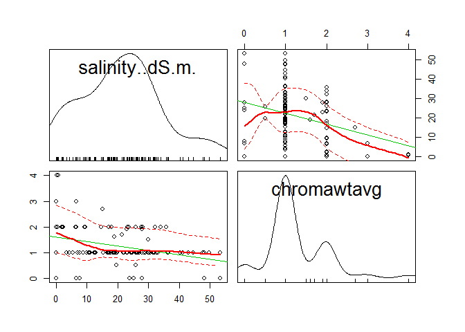

```r
spm(kssl.join.ec)
```

```r
kssl.join.ec.aeric <- kssl.join.ec[kssl.join.ec$chromawtavg >=3, ]

library(Hmisc)
describe(kssl.join.ec.aeric$salinity..dS.m.)
```

```
## kssl.join.ec.aeric$salinity..dS.m.
##        n  missing distinct     Info     Mean      Gmd
##        4        0        4        1    1.955     3.37
##
## Value      0.00 0.40 0.82 6.60
## Frequency     1    1    1    1
## Proportion 0.25 0.25 0.25 0.25
```

```r
median(kssl.join.ec.aeric$salinity..dS.m.)
```

```
## [1] 0.61
```

Very little EC data exists for PHorizons with Aeric features (Chroma >= 3)

The RV value of 0.6 could be applied to CHorizon data representing an Aeric feature horizon, however the L and H ranges should still reflect the general range for EC as Aeric features are elusive in terms of depth even amongst components where they may be common.

There is currently no EC 1:5 data for PHorizons with chroma >= 3.